# Fundamentals of R

## Bar plots: Life expectancy from 1957 to 2007 across continents

To create bar plot in ggplot2 we use the [`geom_col()`](https://ggplot2.tidyverse.org/reference/geom_col.html) function.

[What are bar plots good for?](https://www.data-to-viz.com/graph/barplot.html)

Let’s start with a simple bar plot, one continent at two different points in time.

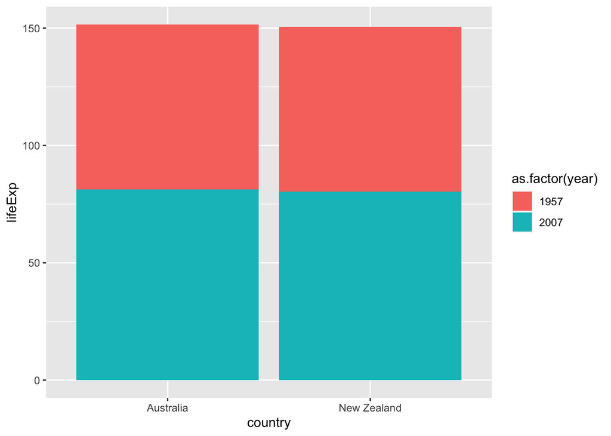

```r
gapminder %>% # select data
  filter(year == 1957 | year == 2007,
         continent == "Oceania") %>% # filter for years of interest and Oceania
  ggplot(aes(x = country, # country in the x axis
             y = lifeExp, # map average life expectancy in the y axis
             fill = as.factor(year))) +
  # map fill by year (as factor), fill means the color filling the geom...
  geom_col()
```

What is the issue with this plot?

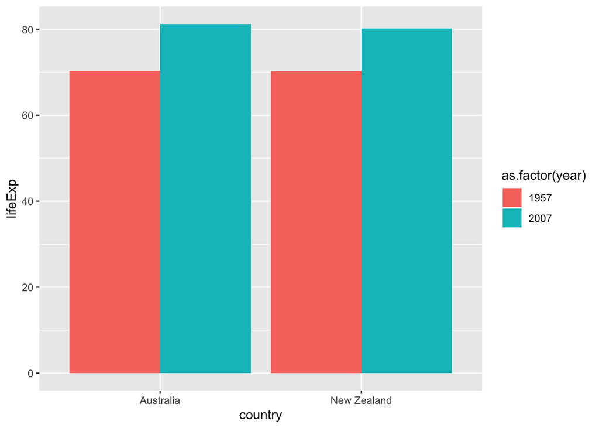

```r
gapminder %>% # select data
  filter(year == 1957 | year == 2007,
         continent == "Oceania") %>% # filter for years of interest and Oceania
  ggplot(aes(x = country, # country in the x axis
             y = lifeExp, # map average life expectancy in the y axis
             fill = as.factor(year))) +
  # map fill by year (as factor), remember that fill means the color filling the geom
  geom_col(position= "dodge") # separated the columns
```

This looks nicer, but there are several improvements we can still make!

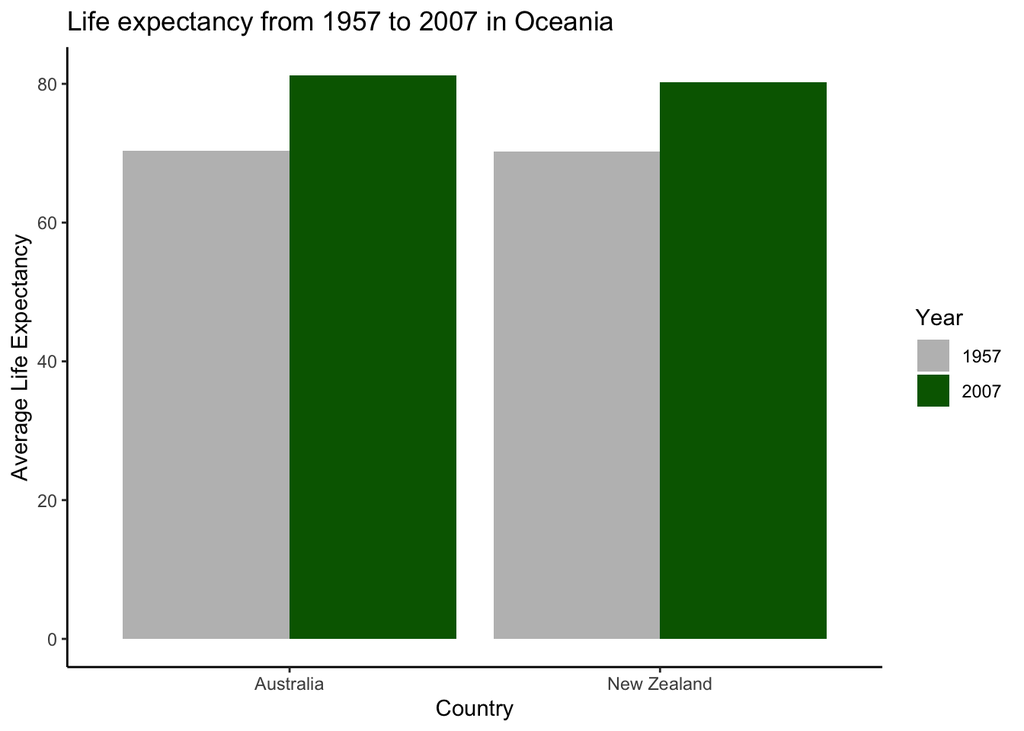

```r
gapminder %>% # select data
  filter(year == 1957 | year == 2007,
         continent == "Oceania") %>% # filter for years of interest and Oceania
  ggplot(aes(x = country, # country in the x axis
             y = lifeExp, # map average life expectancy in the y axis
             fill = as.factor(year))) +
  # map fill by year (as factor), remember that fill means the color filling the geom
  geom_col(position= "dodge") + # separated the columns
  labs(title = "Life expectancy from 1957 to 2007 in Oceania", # add a title
       x = "Country", # add a label for x axis
       y = "Average Life Expectancy", # add a label for y axis
       fill = "Year") + # sub legend for fill
  scale_fill_manual(values = c("gray", "darkgreen")) + # manually set colors
  theme_classic()
```

```r
  # adds a theme; theme_classic is a "clean" theme that removes unnecessary stuff
```

Lastly, let’s use the same bar plots the average difference in life expectancy from 1957 to 2007 across continents.

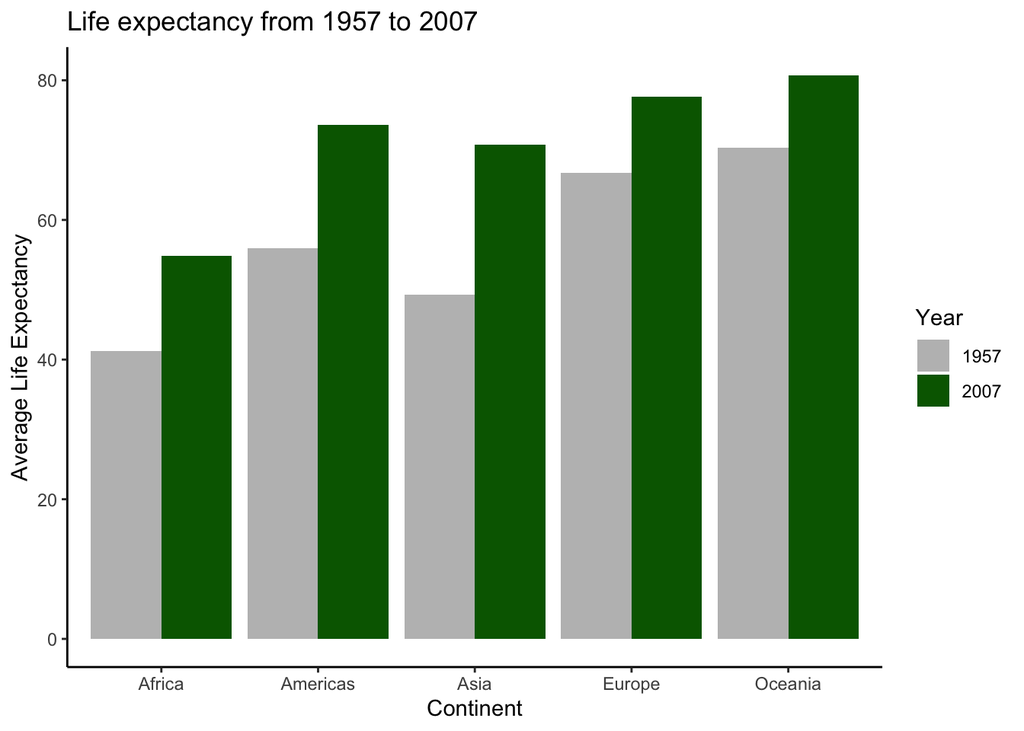

```r
gapminder %>% # select data
  filter(year == 1957 | year == 2007) %>% # filter for years of interest
  group_by(continent, year) %>% # group by year and country
  summarise(Avg_life_expectancy = mean(lifeExp)) %>% # get the means by the groups
  ggplot(aes(x = continent, # map continent in the x axis
             y = Avg_life_expectancy, # map average life expectancy in the y axis
             fill = as.factor(year))) + # fill mapping by year
  geom_col(position = "dodge") + # defining the position of stat in bars
  labs(title = "Life expectancy from 1957 to 2007", # add a title
       x = "Continent", # add a label for x axis
       y = "Average Life Expectancy", # add a label for y axis
       fill = "Year") + # sub legend for fill
  scale_fill_manual(values = c("gray", "darkgreen")) + # manually set colors
  theme_classic() # add a theme
```

## Box plots: Distribution of life expectancies across continent

[What are box plots good for?](https://www.r-bloggers.com/2021/11/how-to-make-stunning-boxplots-in-r-a-complete-guide-with-ggplot2/)

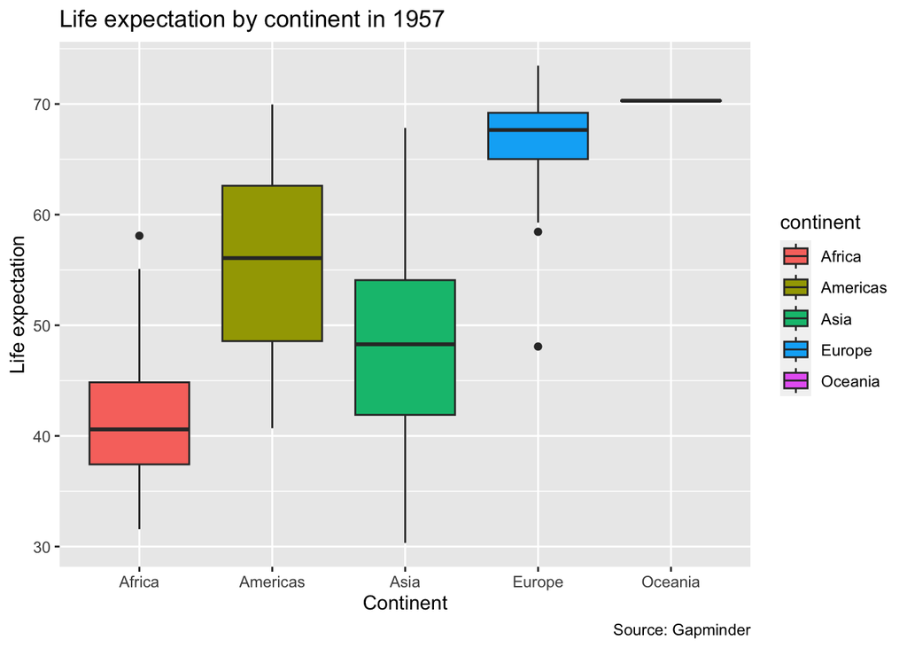

```r
gapminder %>% # get data
  filter(year == 1957) %>% # filter by year
  ggplot(aes(x = continent, y = lifeExp, fill = continent)) + # map first layer
  geom_boxplot() + # box plot
  labs(title = "Life expectation by continent in 1957", # adds title
       x = "Continent", # adds x axis label
       y = "Life expectation", # adds y axis label
       caption = "Source: Gapminder") # adds caption
```

There is a lot of redundant information in this plot, no?

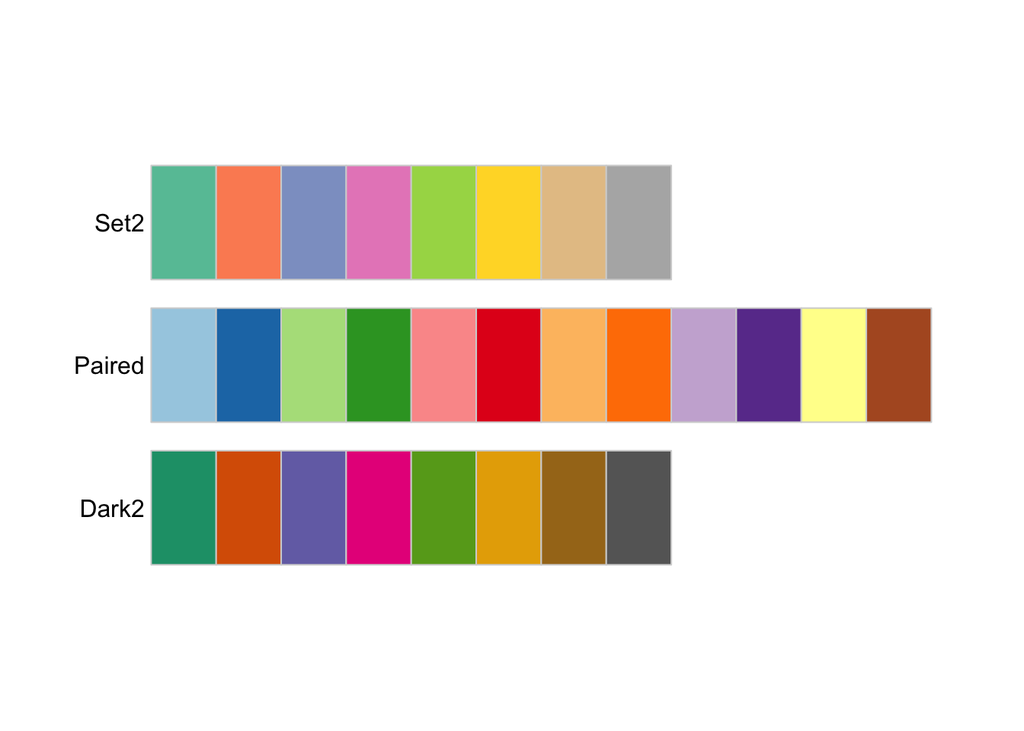

```r
library(RColorBrewer)
display.brewer.all(colorblindFriendly = TRUE, type = "qual")
```

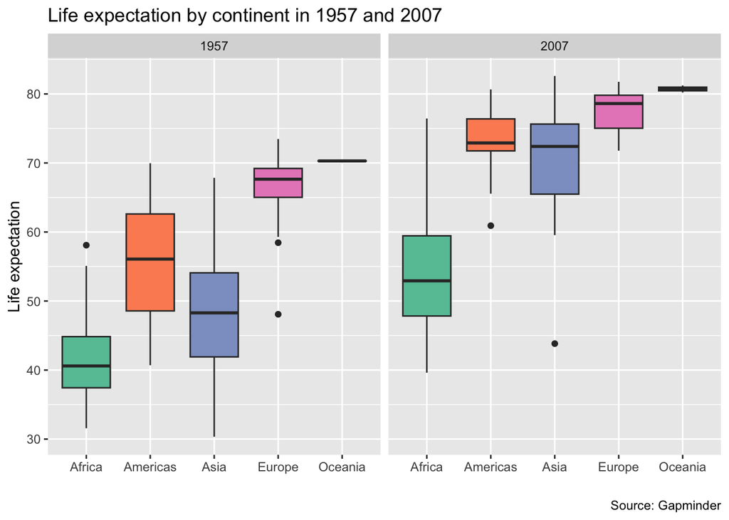

```r
# "qual" stands for qualitative!
gapminder %>%
  filter(year == 1957 | year == 2007) %>% # filter
  ggplot(aes(x = continent, y = lifeExp, fill = continent)) + # fill by continent
  geom_boxplot() + # box plot
  facet_wrap(~year) + # separate plots by year; 2 different plots in this case
  labs(title = "Life expectation by continent in 1957 and 2007",
       x = "", # remove labels for x axis
       y = "Life expectation",
       caption = "Source: Gapminder") +
  theme(legend.position="none") +
  scale_fill_brewer(palette = "Set2")
```

```r
#scale_fill_brewer() colours the aesthetics fill with the "Set2"
```

Could you make the same box plot for GDP?

## Scatter plots: Population, life expectancy and GDP

To create scatter plots in ggplot2 we use the [`geom_point()`](https://ggplot2.tidyverse.org/reference/geom_point.html) function.

[What are scatter plots good for?](https://chartio.com/learn/charts/what-is-a-scatter-plot/)

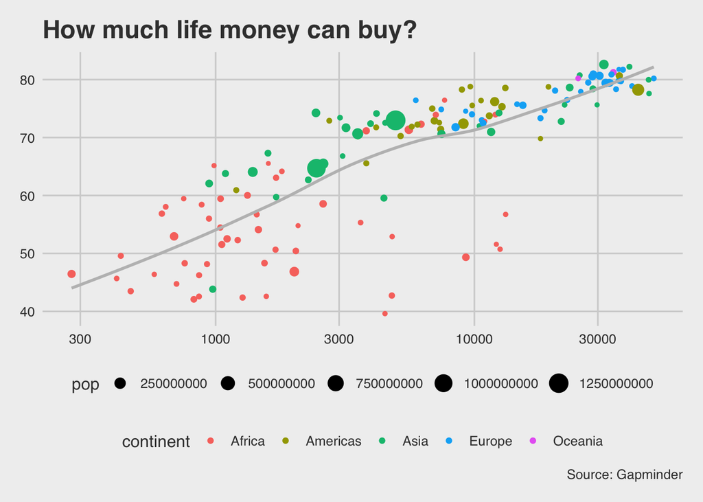

```r
library(ggthemes) # This package has several aditional cool themes!
gapminder %>%
  filter(year == 2007) %>%
  ggplot(aes(x = gdpPercap, y = lifeExp)) +
  geom_point(aes(size = pop, color = continent)) +
  # size points by population and color by continent
  geom_smooth(se = FALSE, color = "gray") + # add a smoothed line
  labs(title = "How much life money can buy?",
       x = "GDP per capita",
       y = "Life expectation",
       caption = "Source: Gapminder") + # add caption
  scale_x_log10() +
  theme_fivethirtyeight() # add theme from the ggthemes package
```